# Comparisons between Ap54 and Ap27

Periklis Kontoroupis

November 15th, 2018

## Summary of analysis

I selected 12 particles each corresponding to a different endemic setting, allowed 1000 repeated simulations and also kept the population size fixed at 440.

For the Ap27 I tested two cases for the female worm: mating cycle=“1” (gonot_cycle_1), mating cycle=“2” (gonot_cycle_2).

Results are presented by taking the average of outputs and also using the individual simulation runs. I used the outputs at pre-control (year 2000), 10yr and 15yr after the end of the last MDA given in 2014.

Summary of results: (A) summary of average model output (log files), (B) demography, (C) worm load by age, (D) worm prevalence by age, (E) mf count by age, (F) mf prevalence by age, (G) mf intensity by age, (H) parameter space diagnostics for 100,000 particles for ap54

### What has changed from Ap27 to Ap52

1. Fix on the female worm insemination period
2. The reapEvent is scheduled correctly in Ap54: (the reaper visits the population just before the surveillance event), the reaper is working more effectively
3. The random number generator engine is now based on a the java engine and not the Mersenne twister
4. Demography has changed, the birth-rates are now different.
5. Alot of optimizations…

### What has changed from Ap52 to Ap54

3. fix of a bug that caused very occasional NaNs on the standardized prevalence

### Scenario specification

Simulation characteristics (scenario 158):

Simulation start : year 1850

No MDA : year 2000, 2001, 2002

MDA (65%, annual,IA) : year 2003, 2004, 2005, 2006, 2007, 2008, 2009, 2010, 2011

No MDA : year 2012

MDA (65%, annual,IA) : year 2013, 2014

No MDA : year 2015 - 2030

### Running options on Ap27 and Ap54

Ap27:

For the *avg.bat* I used:

*start /wait /min java -cp .;wormsim.jar;colt.jar Onchosim2.Wormsim -avg -i%1 -r%2-%3*

exit

For the *run.bat* I used:

*start /wait /min java -cp .;wormsim.jar;colt.jar Onchosim2.Wormsim -run -i%1 -r%2-%3 -d*

exit

Ap54:

For the *run.bat* I used:

java -Xms400m -Xmx400m -XX:+UseG1GC –add-modules java.xml.bind -cp .;wormsim.jar;colt.jar;commons-math3-3.6.1.jar Wormsim -run -iscenario_158_1 -r0-999 -d

java -Xms400m -Xmx400m -XX:+UseG1GC –add-modules java.xml.bind -cp .;wormsim.jar;colt.jar;commons-math3-3.6.1.jar Wormsim -avg -iscenario_158_1 -r0-999

### Meso and hyper endemic settings

- Particle 1: [mbr=641, k=0.202, xfoi=0]
- Particle 2: [mbr=870, k=0.508, xfoi=0]
- Particle 3: [mbr=1944, k=0.531, xfoi=0]
- Particle 4: [mbr=3198, k=0.811, xfoi=0]

### Hypo endemic settings wtih variation in the Xfoi

- Particle 5: [mbr=200, k=0.10, xfoi=0.01]
- Particle 6: [mbr=200, k=0.10, xfoi=0.05]
- Particle 7: [mbr=200, k=0.10, xfoi=0.1]
- Particle 8: [mbr=200, k=0.10, xfoi=0.2]
- Particle 9: [mbr=200, k=0.10, xfoi=0.005]
- Particle 10: [mbr=200, k=0.10, xfoi=0.004]
- Particle 11: [mbr=200, k=0.10, xfoi=0.002]
- Particle 12: [mbr=200, k=0.10, xfoi=0.001]

### Special note from Roel on population difference between ap27 and Ap52 at baseline (tested)

*As far as I can see now, this is an error in all previous versions, and Ap52 is OK.*

*The error is very likely in the timing of the reaper.*

*In Ap52, the reaper visits the population just before the surveillance event (delay = -3 hrs for the reaper and -2 hrs for the surveillance event).*

*When resetting the simulation, the reapEvent is scheduled correctly in Ap54, but not in previous versions.*

*In previous versions, the reaper comes at a delay of +1 hour irrespective of what was specified in the input.*

*I am not 100% certain about this, but at least 99% :-)*

*Could you test if setting the delay of the reaper to -1 (i.e. just after the surveillance event) in Ap54 makes the difference disappear?*

Thats what I did and confirmed his suggestion.

### Time to complete calculations on the same pc:

For 1 particle 1000 repeated simulations (mbr=1944, pop=440):

Ap27_gonot_cycle_1: 34 min Ap27_gonot_cycle_1: 31 min

with -o option on Ap27: This was included in the erroneous calculation Cw’ = Cw + fc (instead of - as specified in the manual Cw’ = Cw/(1-fc))

Ap27_gonot_cycle_1: 26 min Ap27_gonot_cycle_2: 26 min

## Typical running parameters at Ap54

nov. 05, 2018 11:24:51 A.M. demography.World start INFO: running LYMFASIM version 2.58Ap54 with scenario_158_3.xml seed= 0

nov. 05, 2018 11:24:51 A.M. demography.World start INFO: running LYMFASIM version 2.58Ap54 with scenario_158_3.xml seed= 1

nov. 05, 2018 11:24:52 A.M. demography.World start INFO: running LYMFASIM version 2.58Ap54 with scenario_158_3.xml seed= 2

nov. 05, 2018 11:24:52 A.M. demography.World start INFO: running LYMFASIM version 2.58Ap54 with scenario_158_3.xml seed= 3

## Typical output from Ap54 (zipped *.mflog)

id seed sample year popmult rbr p1exp xfoi mf+ mf5+ mf6or7 mf20+ w+ N N5+ N6or7 N20 CMFL

1 0 -1 2000.000 0.361 1.160 0.238 0.033 0.286 0.350 0.130 0.421 0.367 360 294 23 190 1.578

1 0 -1 2001.000 0.361 1.160 0.238 0.029 0.266 0.322 0.095 0.395 0.350 357 292 21 190 1.717

1 0 -1 2002.000 0.361 1.160 0.238 0.028 0.283 0.338 0.053 0.427 0.357 361 299 19 192 1.551

1 0 -1 2003.000 0.361 1.160 0.238 0.028 0.278 0.334 0.045 0.427 0.340 353 293 22 185 1.595

## Typical 2nd output from Ap54 (zipped *.uflog)

id sample year popmult rbr p1exp xfoi mf+ mf5+ mf6or7 N N5+ N6or7

1 -1 2000.000 0.361 1.160 0.238 0.033 0.286 0.350 0.130 360 294 23

1 -1 2001.000 0.361 1.160 0.238 0.029 0.266 0.322 0.095 357 292 21

1 -1 2002.000 0.361 1.160 0.238 0.028 0.283 0.338 0.053 361 299 19

1 -1 2003.000 0.361 1.160 0.238 0.028 0.278 0.334 0.045 353 293 22

## (A) Summary results (based on the average output):

```
## [1] "Particle 1 "
```

year

N

N20

mf.

mf.20

mfPr

aNmf

aNmf20

gNmf

CMFL

bl

bl20

blPr

w.20

aNw

aNw20

mbr

mtp

L1

L3

ifoi

xfoi

description

2000

438

214

25.5

37.5

25.4

10.4

17.8

1

1.9

22.5

38.3

22.3

31.3

43.2

1.9

3.2

641

33338.1

338061.5

52009.5

0.72

0

partic_1_ap27a_log

2000

439

214

25.5

37.6

25.3

10.4

17.8

1

2.0

22.5

38.3

22.3

31.4

43.3

1.9

3.2

641

33499.0

339693.4

52260.5

0.72

0

partic_1_ap27b_log

2000

430

210

25.6

37.7

25.5

10.4

18.0

1

2.0

22.5

38.4

22.3

31.5

43.5

1.9

3.2

641

33517.1

339877.0

52288.8

0.72

0

partic_1_Ap54a_log

2000

430

210

25.5

37.5

25.4

10.3

17.7

1

1.9

22.5

38.1

22.3

31.4

43.2

1.9

3.2

641

33408.1

338772.0

52118.8

0.72

0

partic_1_Ap54b_log

```
## [1] "Particle 2 "
```

year

N

N20

mf.

mf.20

mfPr

aNmf

aNmf20

gNmf

CMFL

bl

bl20

blPr

w.20

aNw

aNw20

mbr

mtp

L1

L3

ifoi

xfoi

description

2000

438

214

37.5

56.8

37.3

10.9

18.9

1.6

3.6

33.0

57.7

32.6

45.8

64.2

2.1

3.5

870

35868.4

267982.1

41228.0

0.78

0

partic_2_ap27a_log

2000

438

214

37.5

56.7

37.3

10.7

18.6

1.6

3.6

33.0

57.7

32.6

45.9

64.2

2.1

3.4

870

35697.3

266704.1

41031.4

0.77

0

partic_2_ap27b_log

2000

430

210

37.3

56.5

37.1

10.6

18.5

1.6

3.6

32.9

57.7

32.5

45.8

64.1

2.0

3.4

870

35267.2

263490.5

40537.0

0.77

0

partic_2_Ap54a_log

2000

430

209

37.3

56.7

37.1

10.7

18.8

1.6

3.6

32.8

57.7

32.4

45.8

64.2

2.1

3.4

870

35485.1

265118.4

40787.4

0.77

0

partic_2_Ap54b_log

```
## [1] "Particle 3 "
```

year

N

N20

mf.

mf.20

mfPr

aNmf

aNmf20

gNmf

CMFL

bl

bl20

blPr

w.20

aNw

aNw20

mbr

mtp

L1

L3

ifoi

xfoi

description

2000

439

214

56.3

76.8

56.3

40.0

68.6

5.0

13.0

49.3

77.5

49

63.2

81.2

7.2

12.1

1944

125289.2

418919.7

64449.2

2.73

0

partic_3_ap27a_log

2000

438

214

56.2

76.6

56.3

39.7

67.7

4.9

12.9

49.4

77.5

49

63.1

81.1

7.2

11.9

1944

124272.3

415519.5

63926.1

2.72

0

partic_3_ap27b_log

2000

430

210

56.2

76.7

56.2

39.7

67.7

4.9

12.9

49.4

77.4

49

63.1

81.2

7.2

12.0

1944

124725.1

417033.5

64159.0

2.72

0

partic_3_Ap54a_log

2000

430

210

56.3

76.8

56.3

40.1

68.5

5.0

13.0

49.4

77.5

49

63.2

81.3

7.2

12.0

1944

124721.9

417022.9

64157.4

2.72

0

partic_3_Ap54b_log

```
## [1] "Particle 4 "
```

year

N

N20

mf.

mf.20

mfPr

aNmf

aNmf20

gNmf

CMFL

bl

bl20

blPr

w.20

aNw

aNw20

mbr

mtp

L1

L3

ifoi

xfoi

description

2000

438

214

69.9

90.6

70.1

71.5

121.6

10.6

32.3

61.5

91.2

61.2

75.7

93.0

12.8

21.2

3198

220814.7

448810.4

69047.8

4.84

0

partic_4_ap27a_log

2000

438

214

70.0

90.8

70.2

71.9

122.3

10.6

32.5

61.6

91.2

61.3

75.8

93.1

12.8

21.3

3198

221469.6

450141.5

69252.5

4.84

0

partic_4_ap27b_log

2000

430

210

70.0

90.8

70.2

71.6

122.1

10.6

32.6

61.5

91.2

61.2

75.8

93.1

12.7

21.2

3198

220749.2

448677.3

69027.3

4.83

0

partic_4_Ap54a_log

2000

430

209

70.0

90.6

70.2

71.2

121.1

10.6

32.3

61.4

91.1

61.2

75.7

93.0

12.8

21.2

3198

221700.9

450611.6

69324.9

4.83

0

partic_4_Ap54b_log

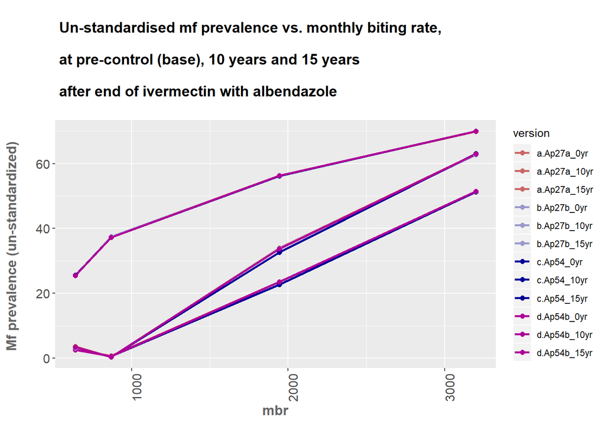

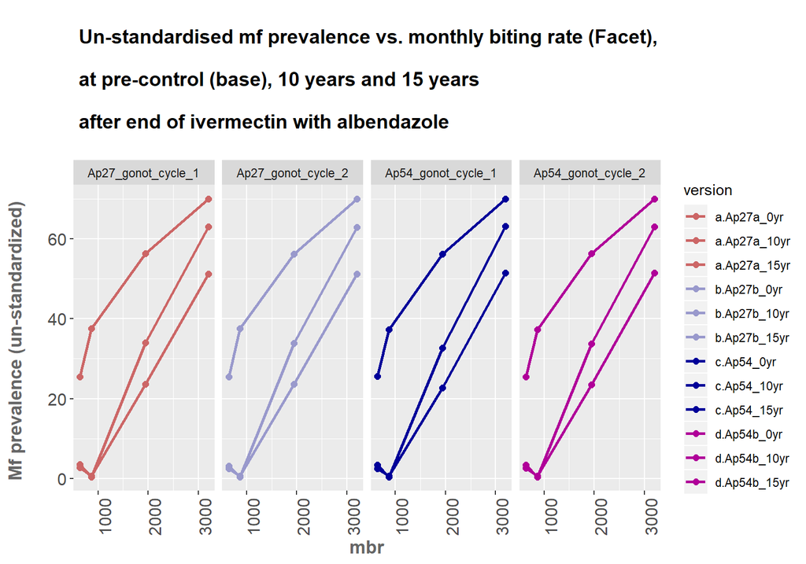

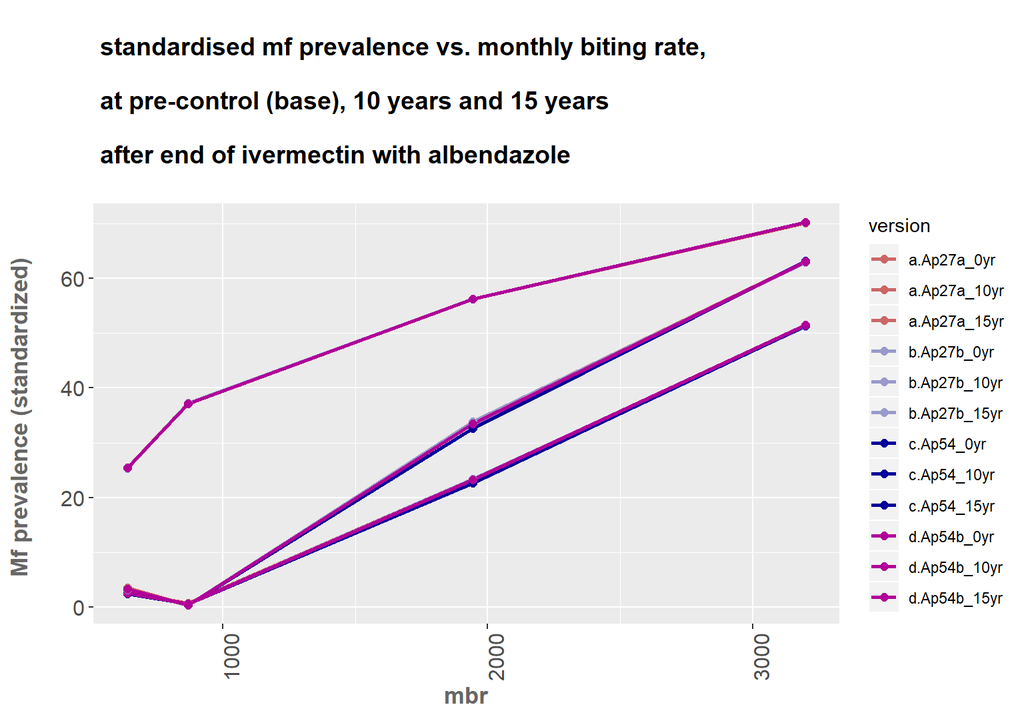

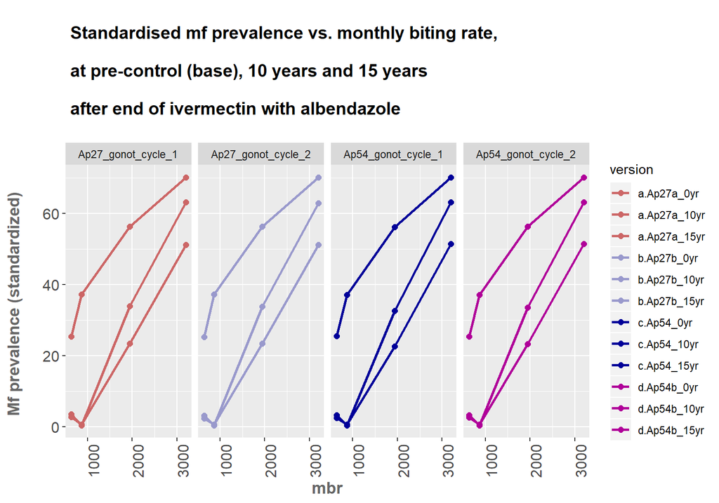

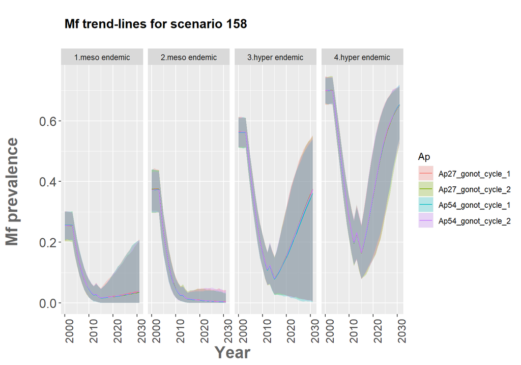

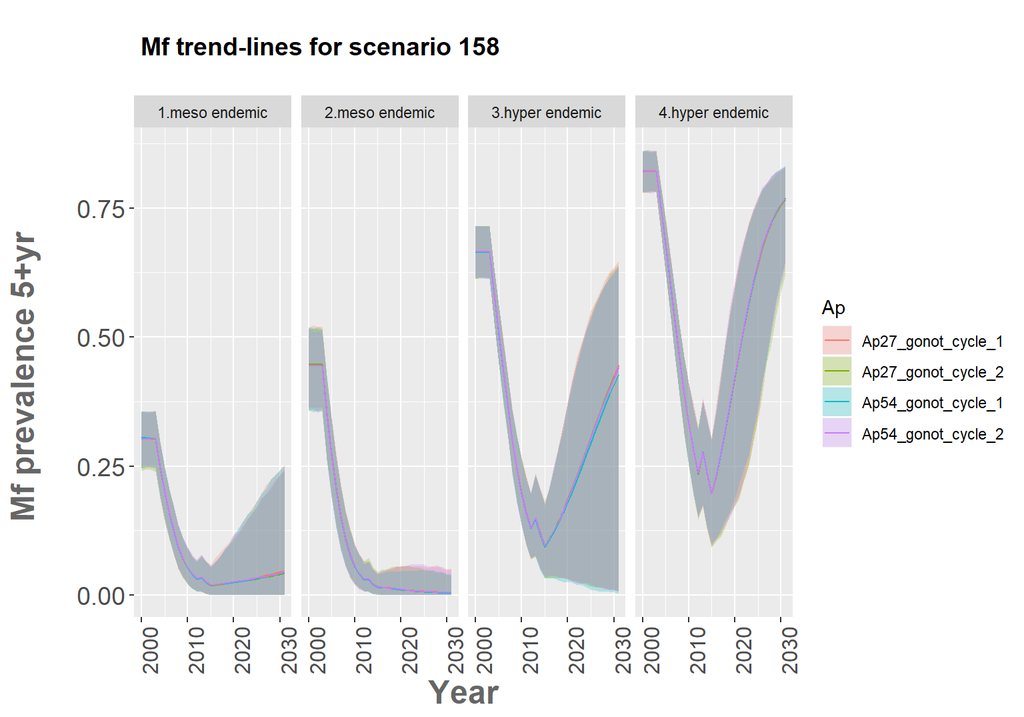

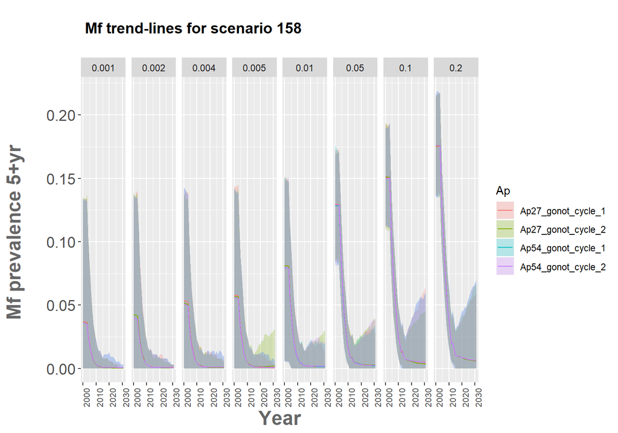

## (B) Demographics:

### Same notes on the demographics

I checked the different versions, the area under the curve is the same.

According to Roel, the reaper removes 5% of the population if pop size > 440. This means that the part of the more or less Gaussian distribution of Ap52 with the reaper after the survey moment (-1h) that is to the right of 440 moves to the left by 22 and is added to the part to the left of 440 (which is not affected). Adding these two distributions (the original until 440 and the part from 440 shifted to the left by 22) results in a more or less uniform distribution

Also about the Gaussian distribution with the reaper at -1: the Gaussian distribution is due to ‘regression to the mean’. The population size are influenced by random processes such as birth and death. ‘Regression to the mean’ simply means that extremes disappear.

```
##                   Ap        N
## 1 Ap27_gonot_cycle_1 438.3557
## 2 Ap27_gonot_cycle_2 438.3254
## 3 Ap54_gonot_cycle_1 429.8152
## 4 Ap54_gonot_cycle_2 429.7776
```

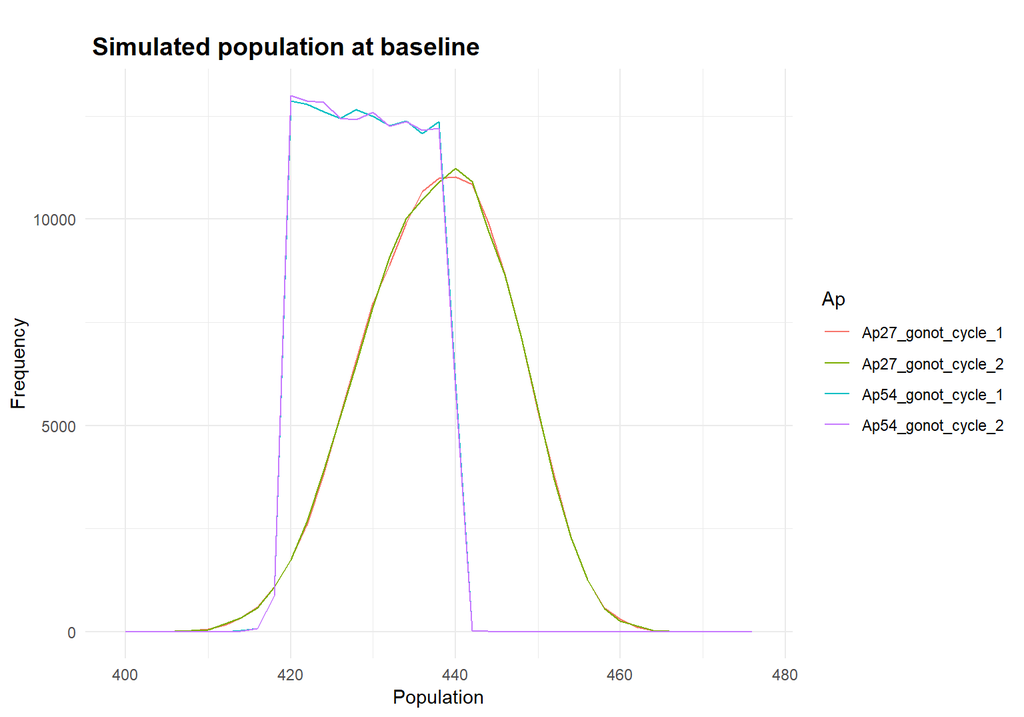

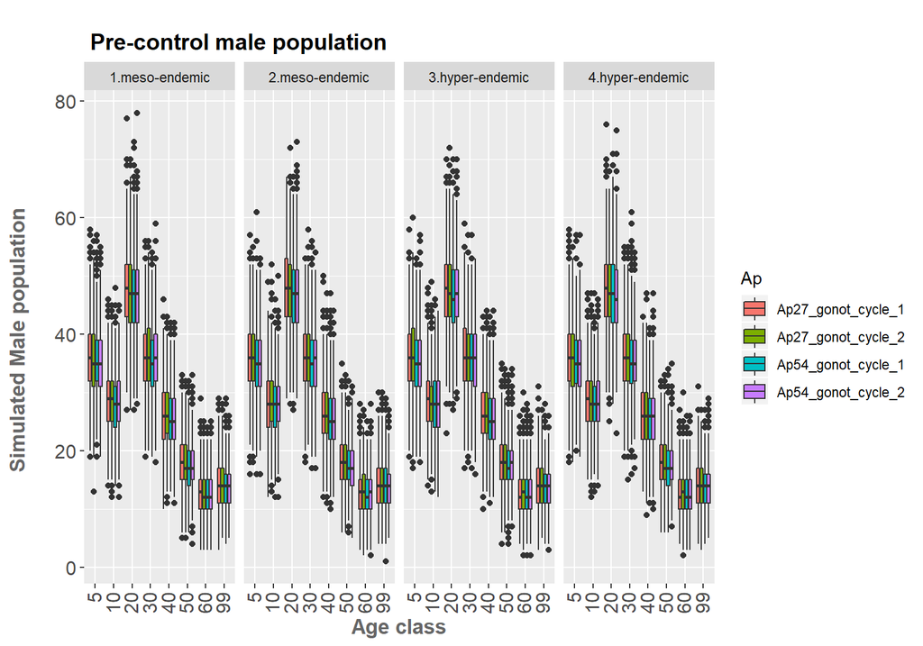

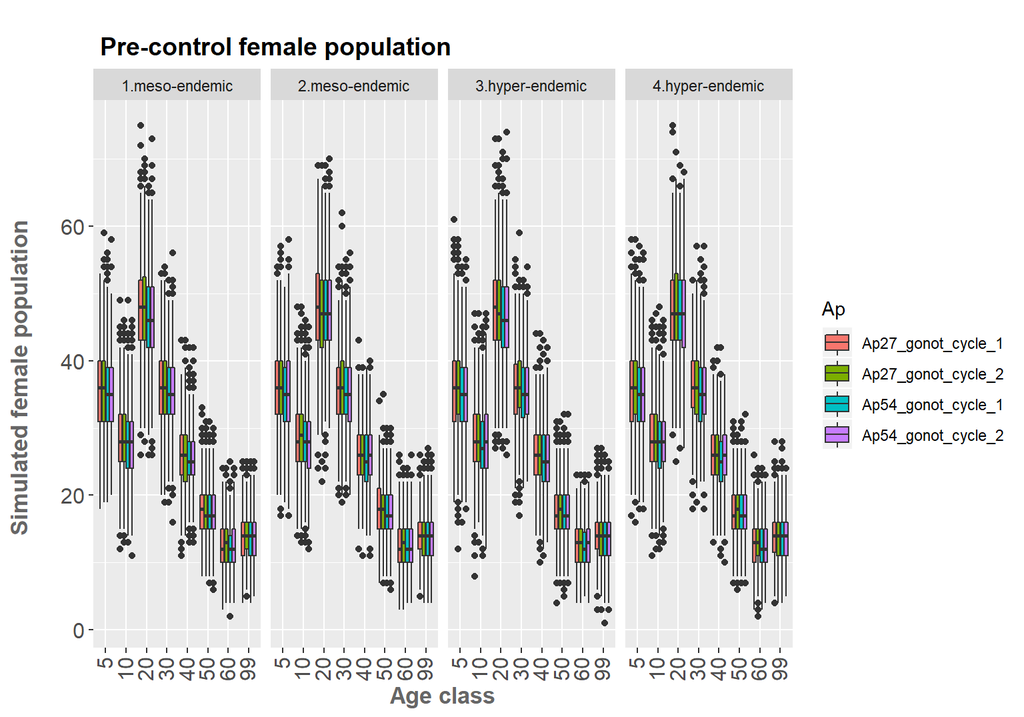

## (C) worm load by age:

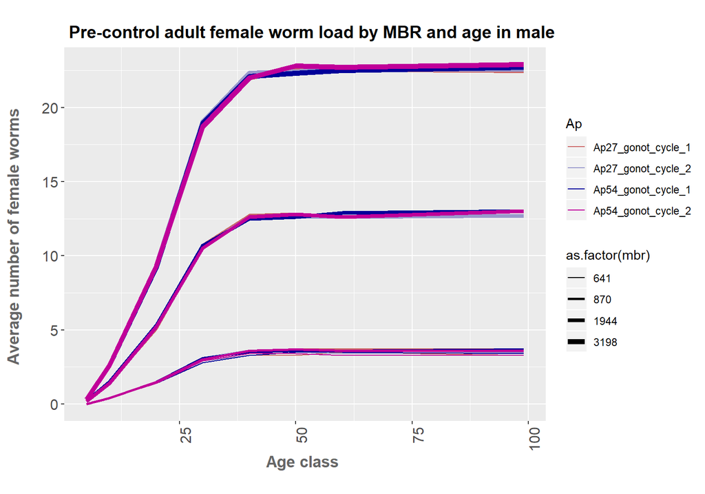

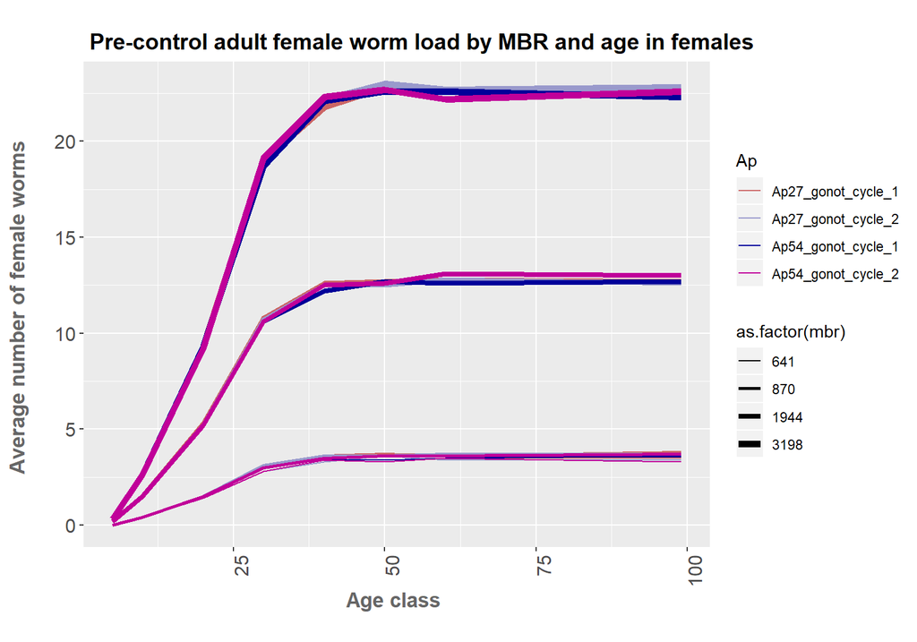

## (D) worm prevavelence by age:

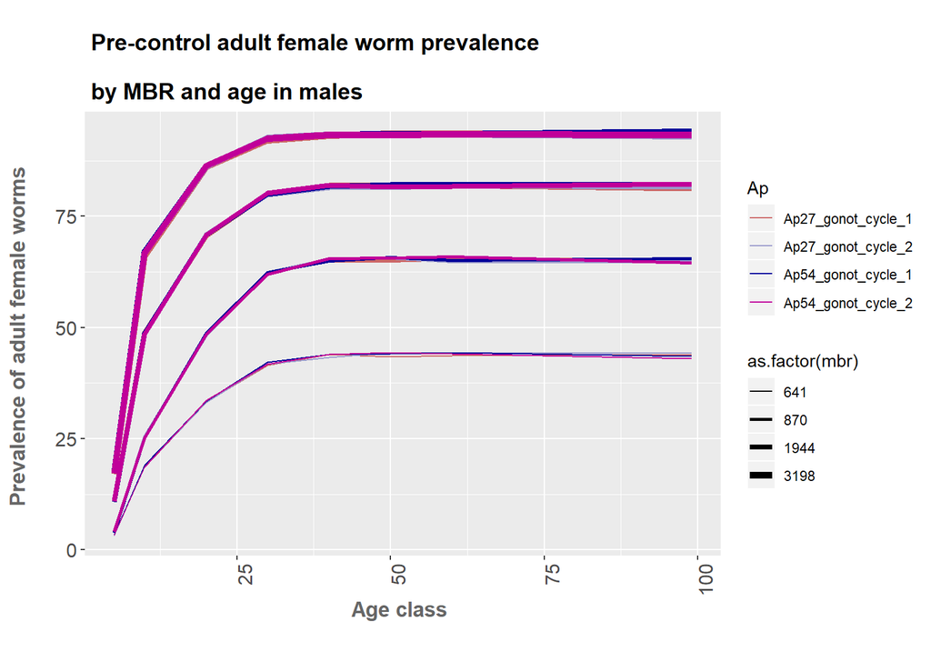

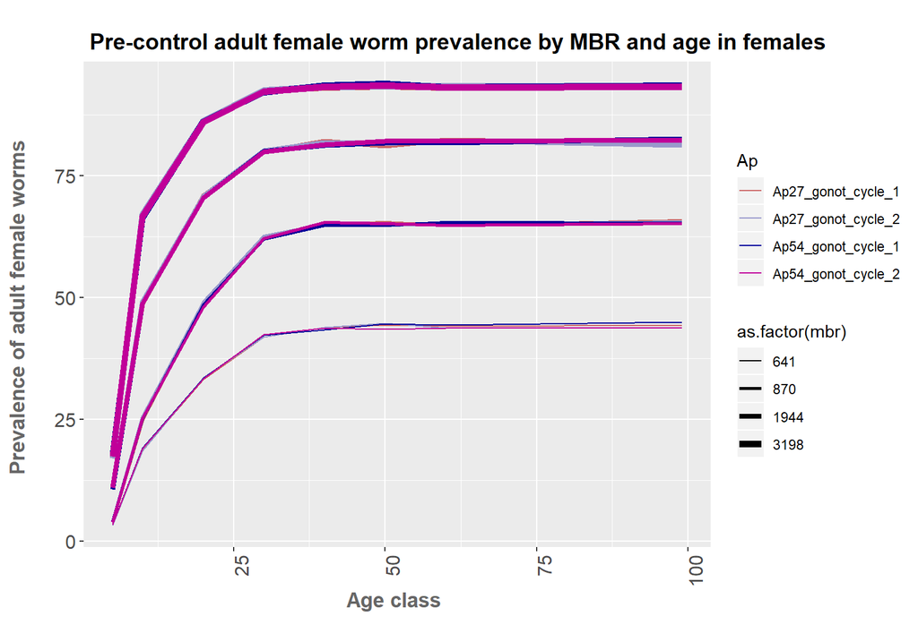

## (E) mf count by age:

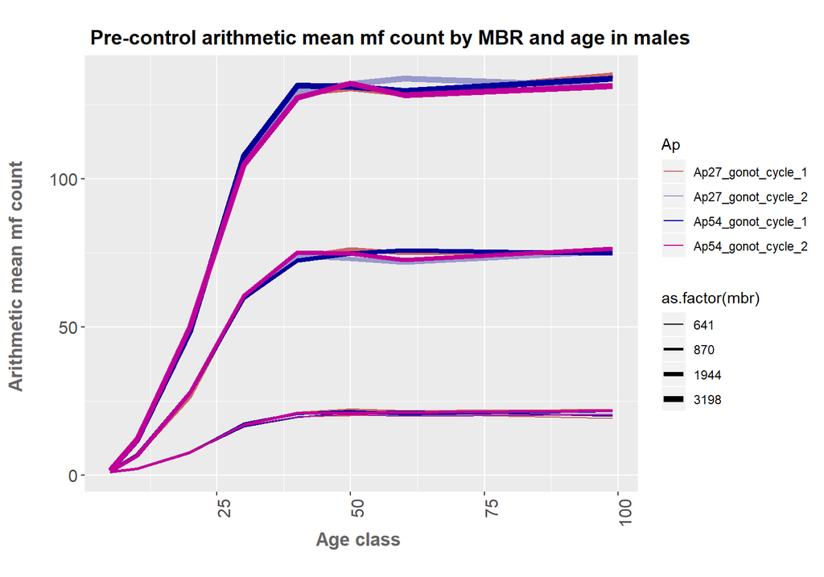

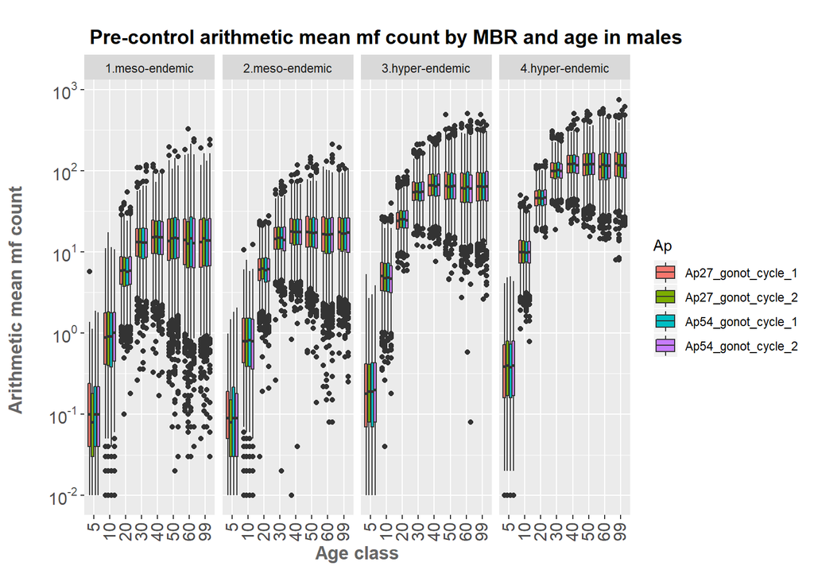

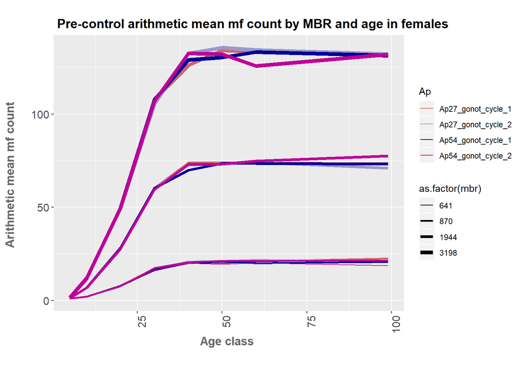

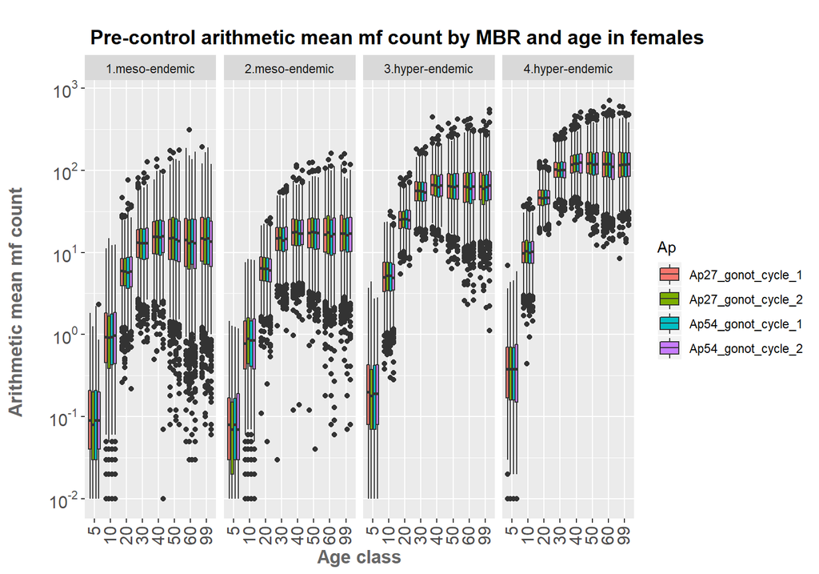

## (F) mf prevalence by age:

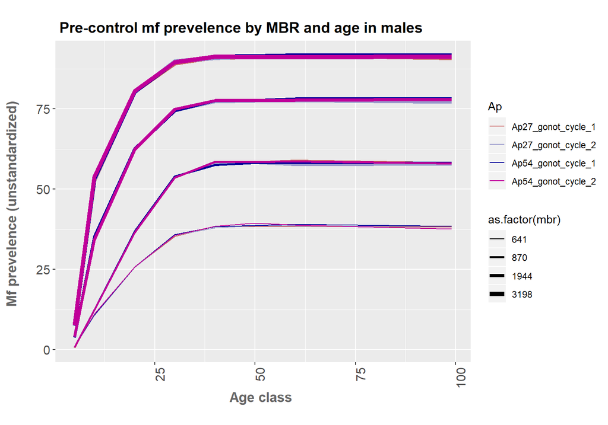

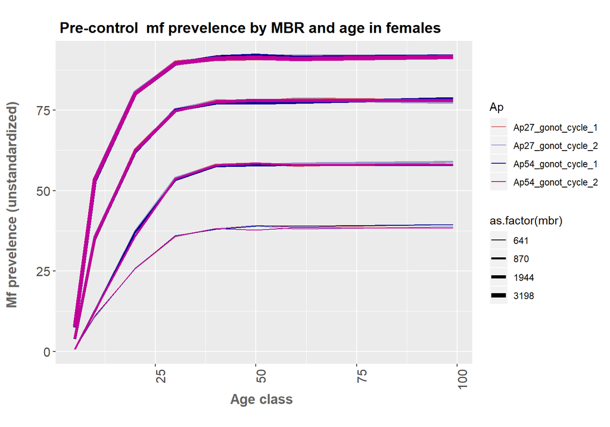

## (G) mf intensity by age:

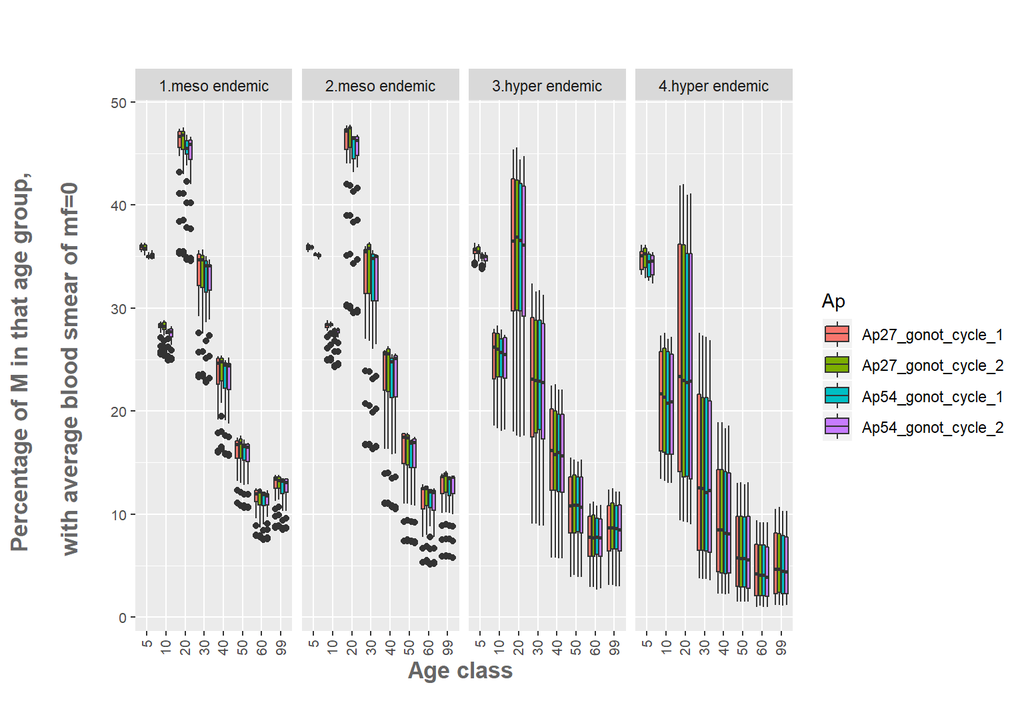

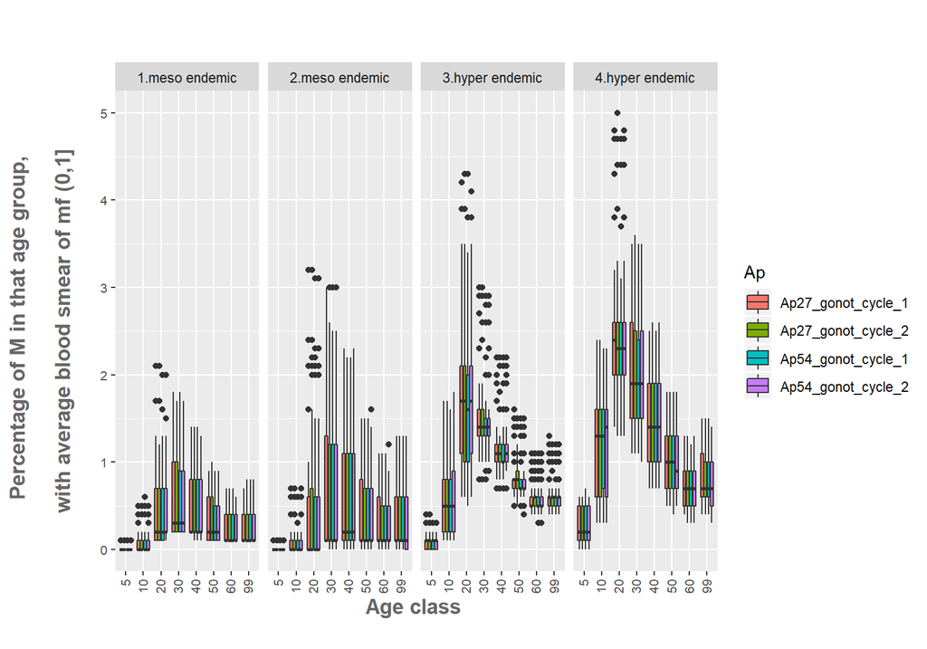

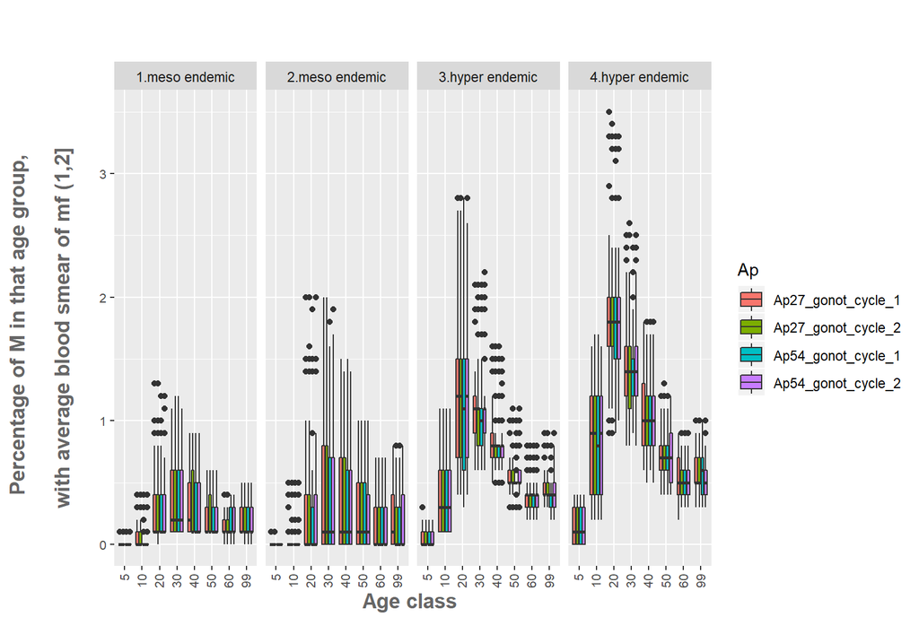

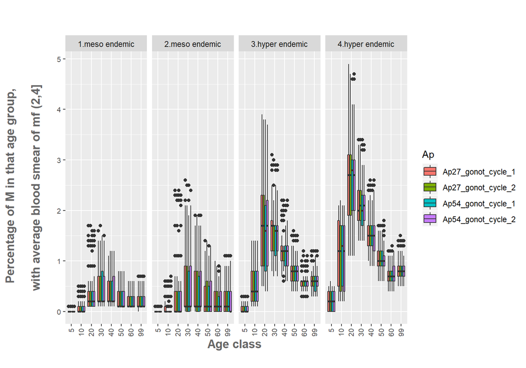

##(H) Paramter-space and other diagnostics

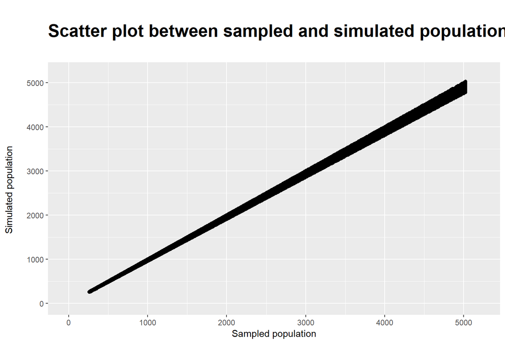

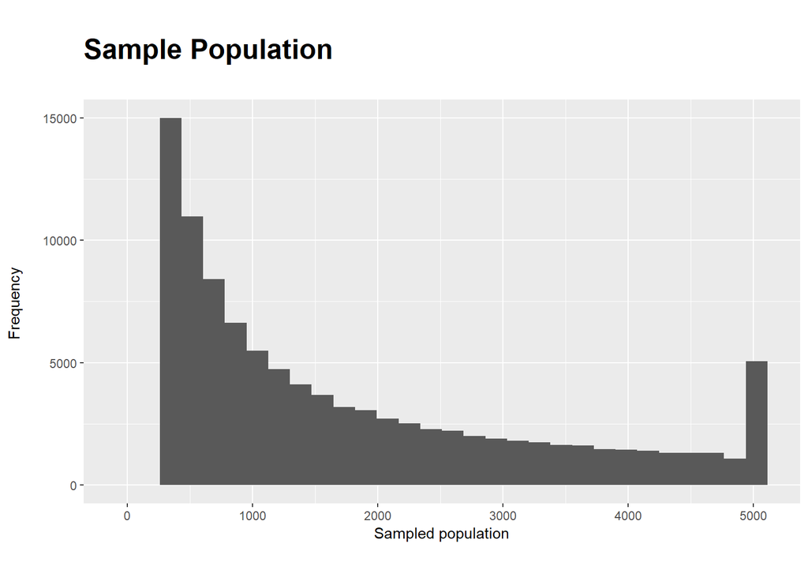

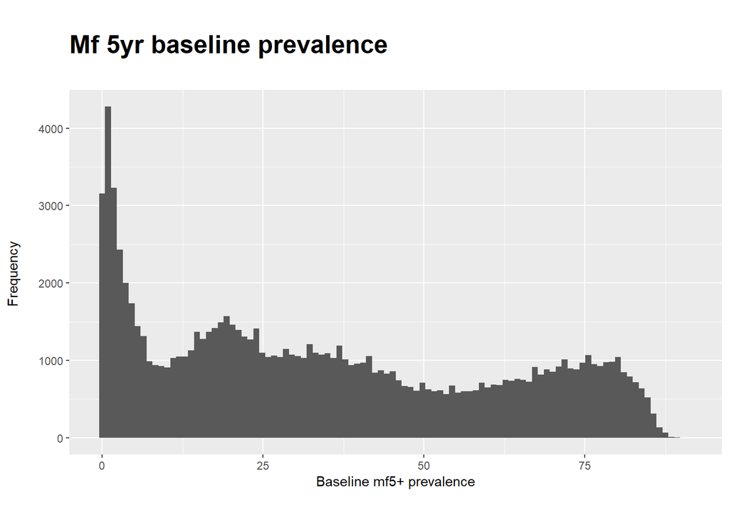

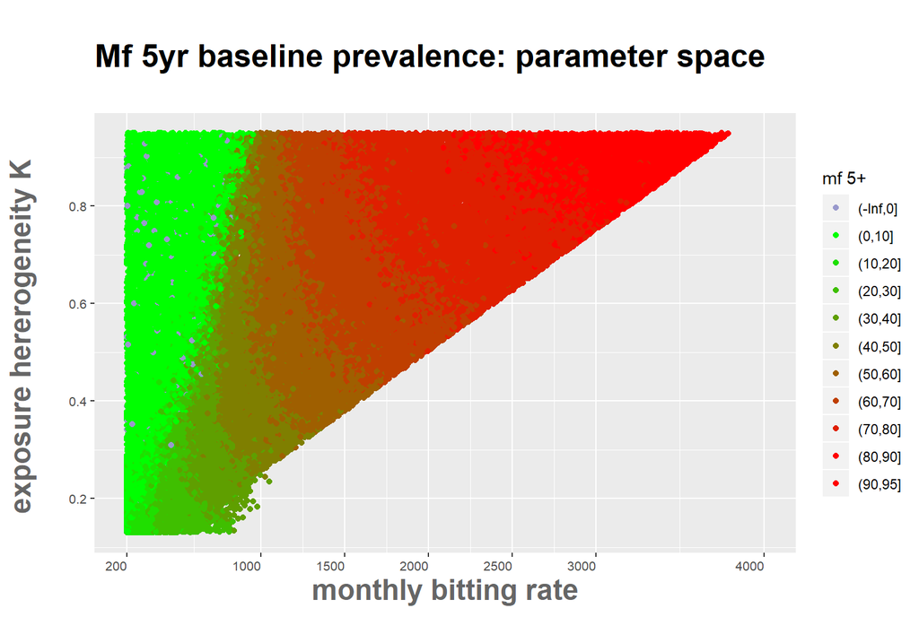

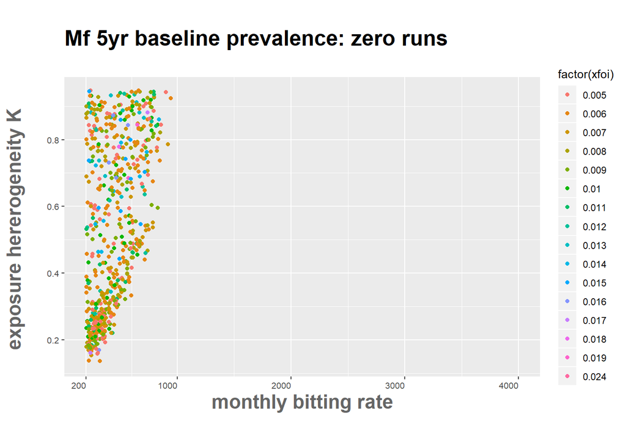